# Reproducible Research: Peer Assessment 1

## Loading and preprocessing the data

1. Set up your own working directory (modify the path below)

```r
setwd("c:/Users/Theseus/Downloads/")
```

2. Read the data (the name of zip file corresponds with file published on github, not original file)

```r
if(!file.exists('activity.csv')){
    unzip('activity.zip')
}
activity <- read.csv('activity.csv')
```

3. Check how data look like

```r
names(activity)
```

```
## [1] "steps"    "date"     "interval"
```

```r
str(activity)
```

```
## 'data.frame':    17568 obs. of  3 variables:
##  $ steps   : int  NA NA NA NA NA NA NA NA NA NA ...
##  $ date    : Factor w/ 61 levels "2012-10-01","2012-10-02",..: 1 1 1 1 1 1 1 1 1 1 ...
##  $ interval: int  0 5 10 15 20 25 30 35 40 45 ...
```

```r
head(activity)
```

```
##   steps       date interval
## 1    NA 2012-10-01        0
## 2    NA 2012-10-01        5
## 3    NA 2012-10-01       10
## 4    NA 2012-10-01       15
## 5    NA 2012-10-01       20
## 6    NA 2012-10-01       25
```

## What is mean total number of steps taken per day?

For this part of the assignment, you can ignore the missing values in the dataset.

1. Make a histogram of the total number of steps taken each day

```r
## (total number of (steps taken per day))
total <- aggregate(steps ~ date, activity, sum)
```

```r
## add name
names(total)[2] <- "sumOfSteps"
```

```r
## summary statistics
summary(total$sumOfSteps)
```

```
##    Min. 1st Qu.  Median    Mean 3rd Qu.    Max.
##      41    8841   10760   10770   13290   21190
```

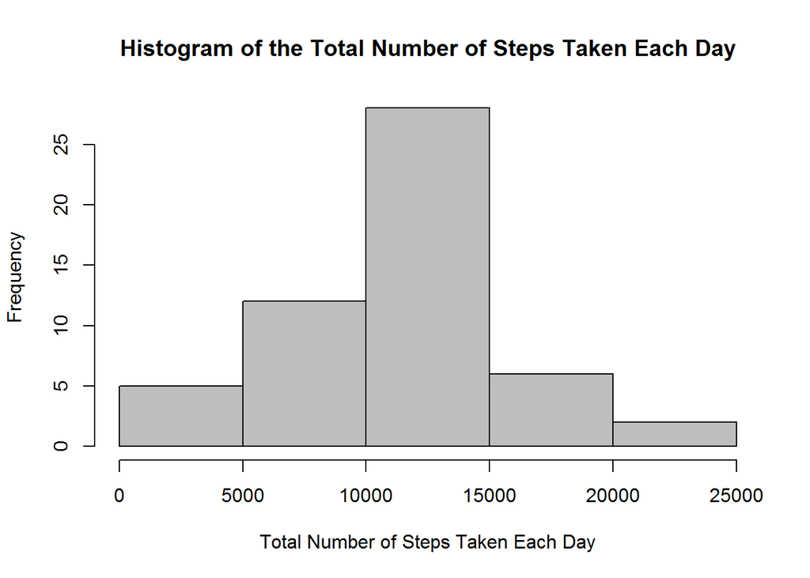

```r
## plot histogram using Sturges rule for breaks
hist(
  total$sumOfSteps,
  col = "gray",
  main = "Histogram of the Total Number of Steps Taken Each Day",
  xlab = "Total Number of Steps Taken Each Day",
  breaks = "Sturges"
)
```

2. Calculate and report the mean and median total number of steps taken per day

```r
## mean
origMean <- mean(total$sumOfSteps)
origMean
```

```
## [1] 10766.19
```

```r
## median
origMedian <- median(total$sumOfSteps)
origMedian
```

```
## [1] 10765
```

## What is the average daily activity pattern?

1. Make a time series plot (i.e. type = “l”) of the 5-minute interval (x-axis) and the average number of steps taken, averaged across all days (y-axis)

```r
## the average number of steps taken, averaged across all days for each 5-minute
## interval
interval <- aggregate(steps ~ interval, activity, mean)
```

```r
## add name of new variable
names(interval)[2] <- "meanSteps"
```

```r
## summary statistics
summary(interval$meanSteps)
```

```
##    Min. 1st Qu.  Median    Mean 3rd Qu.    Max.
##   0.000   2.486  34.110  37.380  52.830 206.200
```

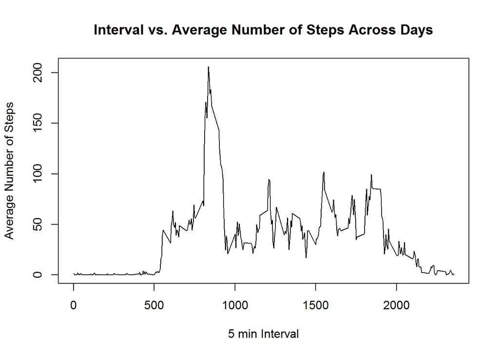

```r
## plot time series
plot(
  x = interval$interval,
  y = interval$meanSteps,
  type = "l",
  main = "Interval vs. Average Number of Steps Across Days",
  xlab = "5 min Interval",
  ylab = "Average Number of Steps"
)
```

2. Which 5-minute interval, on average across all the days in the dataset, contains the maximum number of steps?

```r
subset(interval, meanSteps==max(meanSteps), select=c(interval))
```

```
##     interval
## 104      835
```

## Imputing missing values

1. Calculate and report the total number of missing values in the dataset (i.e. the total number of rows with NAs)

```r
sum(is.na(activity$steps))
```

```
## [1] 2304
```

2. Devise a strategy for filling in all of the missing values in the dataset. The strategy does not need to be sophisticated. For example, you could use the mean/median for that day, or the mean for that 5-minute interval, etc.

A mean for the 5-minute interval will be used in next step for simple imputation of missing values.

3. Create a new dataset that is equal to the original dataset but with the missing data filled in.

```r
## merge original activity data frame with interval data frame
## all.y = F must be set up as a condition
imputed <- merge(activity, interval, by = 'interval', all.y = F)
```

```r
## check correctness of merge
head(imputed)
```

```
##   interval steps       date meanSteps
## 1        0    NA 2012-10-01  1.716981
## 2        0     0 2012-11-23  1.716981
## 3        0     0 2012-10-28  1.716981
## 4        0     0 2012-11-06  1.716981
## 5        0     0 2012-11-24  1.716981
## 6        0     0 2012-11-15  1.716981
```

```r
## impute missing values using mean
## imputed$steps[is.na(imputed$steps)] <- round(imputed$meanSteps) doesn't work
## and generate warning + doesn't impute properly
imputed$steps[is.na(imputed$steps)] <- round(imputed$meanSteps[is.na(imputed$steps)])
```

```r
## drop column with means
imputed <- imputed[,-4]
```

4. Make a histogram of the total number of steps taken each day and Calculate and report the mean and median total number of steps taken per day.

```r
## data frame with sums based on imputed data frame
totalImp <- aggregate(steps ~ date, imputed, sum)
```

```r
## add names again
names(totalImp)[2] <- "sumOfSteps"
```

```r
## check out new data frame
summary(totalImp)
```

```
##          date      sumOfSteps
##  2012-10-01: 1   Min.   :   41
##  2012-10-02: 1   1st Qu.: 9819
##  2012-10-03: 1   Median :10762
##  2012-10-04: 1   Mean   :10766
##  2012-10-05: 1   3rd Qu.:12811
##  2012-10-06: 1   Max.   :21194
##  (Other)   :55
```

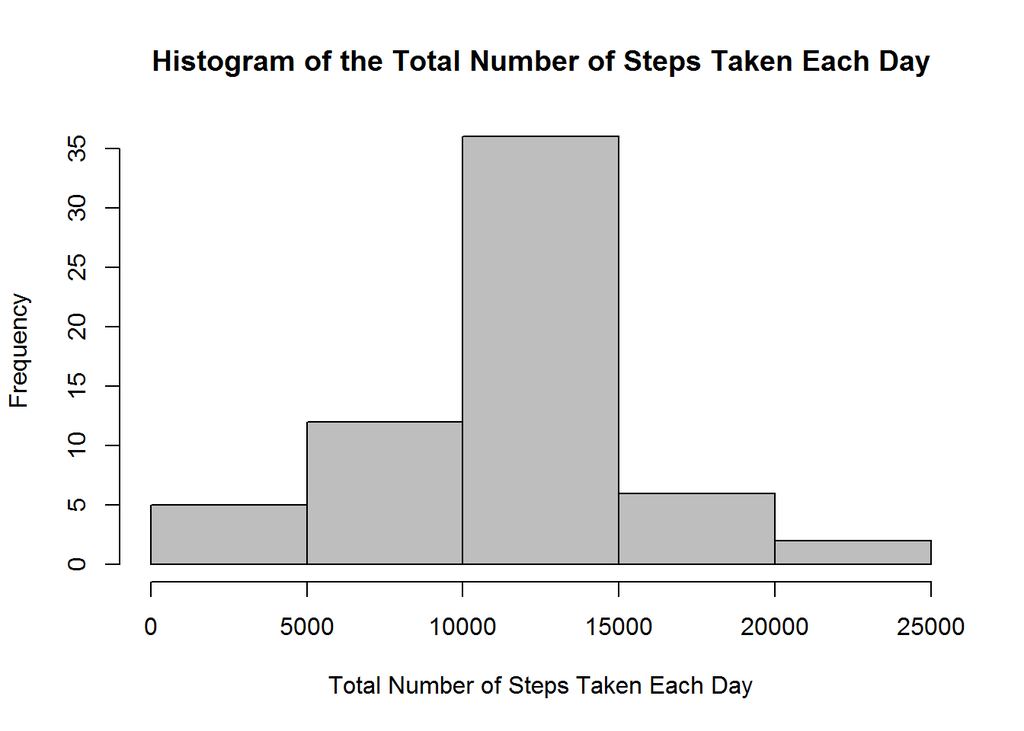

```r
## plot histogram using Sturges rule for breaks
hist(
  totalImp$sumOfSteps,
  col = "gray",
  main = "Histogram of the Total Number of Steps Taken Each Day",
  xlab = "Total Number of Steps Taken Each Day",
  breaks = "Sturges"
)
```

```r
## mean
impMean <- mean(totalImp$sumOfSteps)
impMean
```

```
## [1] 10765.64
```

```r
## median
impMedian <- median(totalImp$sumOfSteps)
impMedian
```

```
## [1] 10762
```

Do these values differ from the estimates from the first part of the assignment? What is the impact of imputing missing data on the estimates of the total daily number of steps?

Original mean:

```
## [1] 10766.19
```

Imputed mean:

```
## [1] 10765.64
```

Original median:

```
## [1] 10765
```

Imputed median:

```
## [1] 10762
```

After imputation small difference in medians (median decreased after imputation), imputed mean moved towards original median.

## Are there differences in activity patterns between weekdays and weekends?

For this part the weekdays() function may be of some help here. Use the dataset with the filled-in missing values for this part.

```r
## create new data frame based on imputed data
copyOfImp <- imputed
```

```r
## set up language environment
## without this e.g. in Czech you have to use "sobota" and "ned??le" instead of "Saturday" and "Sunday"
Sys.setlocale("LC_TIME", "English")
```

```
## [1] "English_United States.1252"
```

```r
## logical true/false vector for weekend
weekend <- weekdays(as.Date(copyOfImp$date)) %in% c("Saturday", "Sunday")
```

```r
## add new column daytype and fill in default value weekday
copyOfImp$flag <- "weekday"
```

```r
## replace "weekday" by "weekend" where day corresponds to TRUE in weekend vector
copyOfImp$flag[weekend == TRUE] <- "weekend"
```

```r
## convert new character column to factor
copyOfImp$flag <- as.factor(copyOfImp$flag)
```

```r
## check the result
str(copyOfImp)
```

```
## 'data.frame':    17568 obs. of  4 variables:
##  $ interval: int  0 0 0 0 0 0 0 0 0 0 ...
##  $ steps   : num  2 0 0 0 0 0 0 0 0 0 ...
##  $ date    : Factor w/ 61 levels "2012-10-01","2012-10-02",..: 1 54 28 37 55 46 20 47 38 56 ...
##  $ flag    : Factor w/ 2 levels "weekday","weekend": 1 1 2 1 2 1 2 1 1 2 ...
```

2. Make a panel plot containing a time series plot (i.e. type = “l”) of the 5-minute interval (x-axis) and the average number of steps taken, averaged across all weekday days or weekend days (y-axis). See the README file in the GitHub repository to see an example of what this plot should look like using simulated data.

```r
## the number of steps averaged across all days and intervals
lastDataFrame <- aggregate(steps ~ interval + flag, copyOfImp, mean)
```

```r
## add name for new column
names(lastDataFrame)[3] <- "meanSteps"
```

```r
## check newly created data frame
head(lastDataFrame)
```

```
##   interval    flag  meanSteps
## 1        0 weekday 2.28888889
## 2        5 weekday 0.40000000
## 3       10 weekday 0.15555556
## 4       15 weekday 0.17777778
## 5       20 weekday 0.08888889
## 6       25 weekday 1.57777778
```

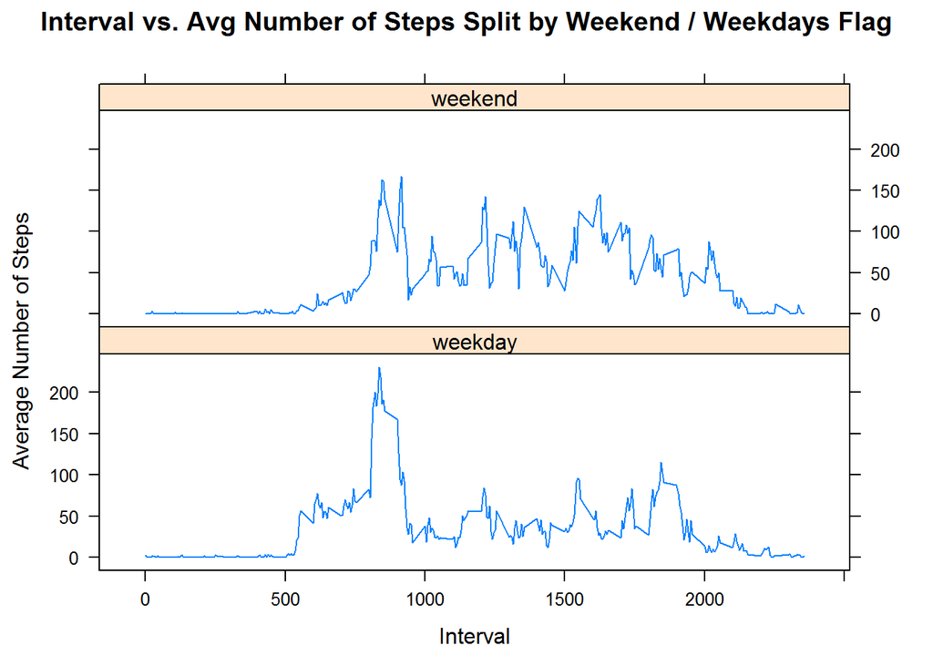

```r
## plot time series using lattice package
library(lattice)
xyplot(
    meanSteps ~ interval | flag,
    lastDataFrame,
    type = "l",
    layout = c(1,2),
    main = "Interval vs. Avg Number of Steps Split by Weekend / Weekdays Flag",
    xlab = "Interval",
    ylab = "Average Number of Steps"
)
```